# communicate_data_finding_slide slides

## Analyzing Ford GoBike System Data

#### by Mostafa Rezk

##### Introduction

- Ford GoBike is a regional public bicycle sharing system in the San Francisco Bay Area,California across San Francisco, East Bay and San Jose
- Beginning operation in August 2013 as Bay Area Bike Share Renting Bikes is designed with convenience in mind. it’s a fun and affordable way to get around town the Ford GoBike system currently has over 2,600 bicycles in 262 stations across San Francisco, East Bay and San Jose
- It aslo offers Single Ride is 2 dollars per day Monthly Memberships is 15 dollars per month Monthly Memberships is 15 dollars per month
- Ford GoBike, consists of a bikes that are locked into a network of docking stations throughout the city. The bikes can be unlocked from one station and returned to any other station in the system, making them ideal for one-way trips. The bikes are available for use 24 hours/day, 7 days/week, 365 days/year and riders have access to all bikes in the network when they become a member or purchase a pass.

### the structure of your dataset

> The data originally had 183412 entries with 16 features. Null values and irresonable data were removed and new features were added to have an updated 174952 entries in the dataset with 20 features; some are numerical and some are categorical and 2 are datetime. The data represents the rides during February of 2019

### the main feature(s) of interest in your dataset

> The duration of a trips correlated by other variables

### features in the dataset I think will help support my investigation

- I will search on peak hours of the day, day of the week and the point of bottom
- the age of bikers , gender and if he or she subscriber or customers
- the affect of 'bike_share_for_all_trip'

## Univariate Exploration

> start by looking at some rides distribution :

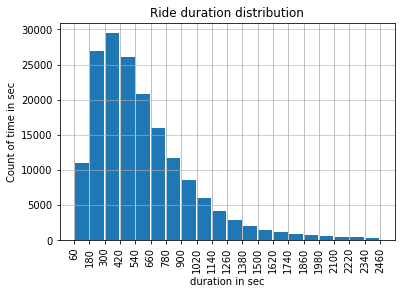

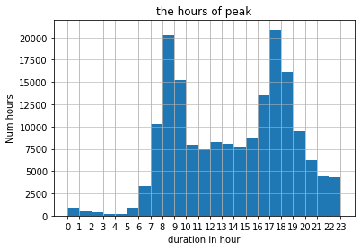

### Discussion of the distribution(s) of your variable(s) of interest. Were there any unusual points

- I checked each variables like the duration of riding bike weekdays and peak hours ,age groups bike riders,genders wise rides etc.

### features I investigated were I find unusual distributions

- I calculate Birth year by substracting the year from current year so this gives us a distibution for also ,I generated new columns to calculate weekdays,days of month,hours

  > age gives a better better perception regarding trip duration dependence also split column date will help us in investigation about the duration of trip and its correlation

## Bivariate Exploration

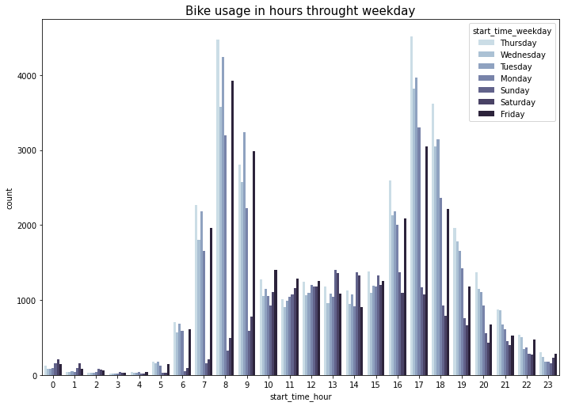

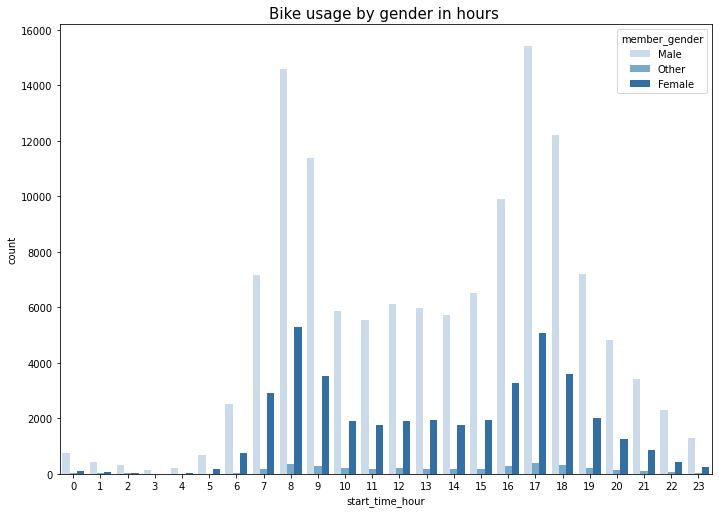

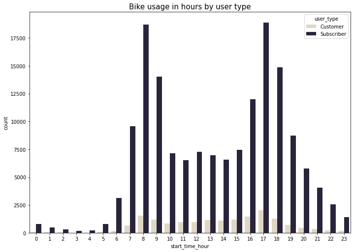

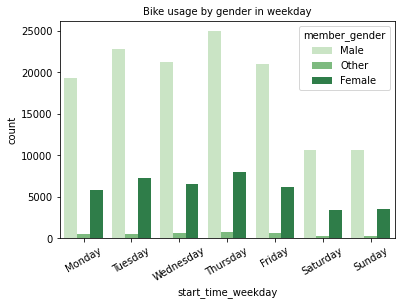

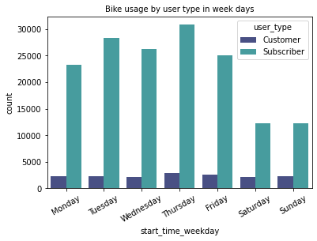

### I observe interesting relationships between the other features

- I thought that variables which are user type , gender and age values having higher value to get higher trip duration i suggest to investigate more about the correlation betwean those variables

## Multivariate Exploration

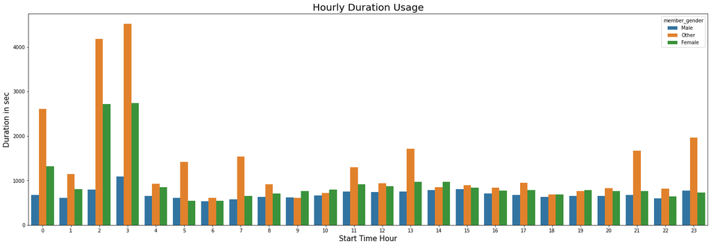

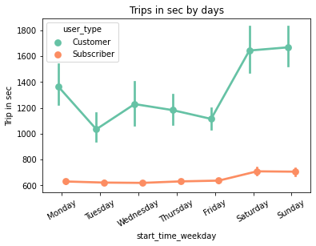

### some of the relationships I observed in this part of the investigation. Were there features that strengthened each other in terms of looking at your feature(s) of interest?

- Subscribers have stable duration usage than Customers who have unstable usage
- intensely Subscribers use our services at peak hour, incontrast the Customers have more flexible time
- males have stable duration usage than female and others who have unstable usage
- subscriber and customer have increased trip duration on saturday and sunday
- subscriber trips are more shorter and quicker compared to customer
- more effictive usage for subscriber and consistent average duration

### Were there any interesting or surprising interactions between features?

- average duration at 3.00 AM is most high by female and others

  > It's kind of surprise that average duration at 3.00 AM is most high than in other hour suggest there were group trip or there were event